# Analysis of dumps

## Raw Data

The test suite stores tcpdump output in a json format. Because this contains information about each packet, it can be parsed to determine information that would not normally be revealed by the transfer program itself. For example, how much overhead or compression there was.

```python
from helpers import get_dump_fnames, get_dumps, organize_dumps

PROTOCOLS = ["scp", "hpn-scp", "ftp", "gridftp"]
N = None # The number of records to retrieve (None=all)

# Find the relevant dumps
names = get_dump_fnames(PROTOCOLS, N)
dumps = get_dumps(names)

# Fetch relevant columns and rename them
df, ids = organize_dumps(dumps)
```

```python
df
```

|  | Protocol | Batch ID | Stored Packets | Start Time | File Size (bytes) | Bytes Down | Bytes Up | Bytes Total | Ratio (%) | Time (s) | Speed (bytes/s) |
| --- | --- | --- | --- | --- | --- | --- | --- | --- | --- | --- | --- |
| 0 | ftp | 58 | False | 2015-10-15 14:07:40 | 536870912 | 537872041 | 1281883 | 539153924 | 100.43 | 21.92 | 24537958.07 |
| 1 | ftp | 275 | False | 2015-10-15 14:25:43 | 536870912 | 537945577 | 1288499 | 539234076 | 100.44 | 18.78 | 28644599.41 |
| 2 | ftp | 233 | False | 2015-10-15 14:43:50 | 536870912 | 537960153 | 1296611 | 539256764 | 100.44 | 21.76 | 24722433.50 |
| 3 | ftp | 121 | False | 2015-10-15 15:01:49 | 536870912 | 529905737 | 1264963 | 531170700 | 98.94 | 23.95 | 22125500.50 |
| 4 | ftp | 228 | False | 2015-10-15 15:20:06 | 536870912 | 538010953 | 1273667 | 539284620 | 100.45 | 24.31 | 22131260.92 |
| 5 | ftp | 72 | False | 2015-10-16 01:00:20 | 536870912 | 537795545 | 1315803 | 539111348 | 100.42 | 24.38 | 22058882.08 |
| 6 | ftp | 185 | False | 2015-10-16 01:18:38 | 536870912 | 538108265 | 1312227 | 539420492 | 100.47 | 23.23 | 23164367.84 |
| 7 | ftp | 76 | False | 2015-10-16 01:36:51 | 536870912 | 538005257 | 1284003 | 539289260 | 100.45 | 23.68 | 22719816.60 |
| 8 | ftp | 42 | False | 2015-10-16 01:54:58 | 536870912 | 538055385 | 1284067 | 539339452 | 100.46 | 22.53 | 23881730.36 |
| 9 | ftp | 291 | False | 2015-10-16 02:13:13 | 536870912 | 537805425 | 1289699 | 539095124 | 100.41 | 22.28 | 24138484.07 |
| 10 | ftp | 99 | False | 2015-10-16 11:00:19 | 536870912 | 537783617 | 1338379 | 539121996 | 100.42 | 27.10 | 19844413.91 |
| 11 | ftp | 13 | False | 2015-10-16 11:28:05 | 536870912 | 537958633 | 1292467 | 539251100 | 100.44 | 23.22 | 23167899.78 |
| 12 | ftp | 182 | False | 2015-10-16 11:54:55 | 536870912 | 535424129 | 1284107 | 536708236 | 99.97 | 22.06 | 24271266.05 |
| 13 | ftp | 345 | False | 2015-10-16 12:21:36 | 536870912 | 537951657 | 1307635 | 539259292 | 100.44 | 23.54 | 22852661.72 |
| 14 | ftp | 90 | False | 2015-10-16 12:48:19 | 536870912 | 538131689 | 1290179 | 539421868 | 100.48 | 21.89 | 24583448.56 |
| 15 | ftp | 15 | False | 2015-10-17 01:00:22 | 536870912 | 537809361 | 1312459 | 539121820 | 100.42 | 24.74 | 21738454.37 |
| 16 | ftp | 253 | False | 2015-10-17 01:26:55 | 536870912 | 537856769 | 1299619 | 539156388 | 100.43 | 24.55 | 21908626.03 |
| 17 | ftp | 292 | False | 2015-10-17 01:53:34 | 536870912 | 537840025 | 1276499 | 539116524 | 100.42 | 24.67 | 21801379.21 |
| 18 | ftp | 162 | False | 2015-10-17 02:20:12 | 536870912 | 537934713 | 1277963 | 539212676 | 100.44 | 23.19 | 23196839.72 |
| 19 | ftp | 48 | False | 2015-10-17 02:47:03 | 536870912 | 537820025 | 1274947 | 539094972 | 100.41 | 22.62 | 23776305.26 |
| 20 | ftp | 209 | False | 2015-10-17 11:00:20 | 536870912 | 532586537 | 1298571 | 533885108 | 99.44 | 24.42 | 21809440.50 |
| 21 | ftp | 323 | False | 2015-10-17 11:27:49 | 536870912 | 537830857 | 1326371 | 539157228 | 100.43 | 23.54 | 22847530.03 |
| 22 | ftp | 120 | False | 2015-10-17 11:54:45 | 536870912 | 537884809 | 1324003 | 539208812 | 100.44 | 23.89 | 22515061.07 |
| 23 | ftp | 208 | False | 2015-10-17 12:21:13 | 536870912 | 537856673 | 1274219 | 539130892 | 100.42 | 22.41 | 24000744.00 |
| 24 | ftp | 101 | False | 2015-10-17 12:47:54 | 536870912 | 537848649 | 1312635 | 539161284 | 100.43 | 23.05 | 23333997.79 |
| 25 | ftp | 202 | False | 2015-10-18 01:00:19 | 536870912 | 537859121 | 1277627 | 539136748 | 100.42 | 22.67 | 23725589.81 |
| 26 | ftp | 174 | False | 2015-10-18 01:27:04 | 536870912 | 538061897 | 1285963 | 539347860 | 100.46 | 22.15 | 24291733.50 |
| 27 | ftp | 22 | False | 2015-10-18 01:53:26 | 536870912 | 538131793 | 1282755 | 539414548 | 100.47 | 22.13 | 24316845.59 |
| 28 | ftp | 7 | False | 2015-10-18 02:19:36 | 536870912 | 521706097 | 1259627 | 522965724 | 97.41 | 23.19 | 22497028.76 |
| 29 | ftp | 258 | False | 2015-10-18 02:45:53 | 536870912 | 537885881 | 1294475 | 539180356 | 100.43 | 24.22 | 22208335.30 |
| ... | ... | ... | ... | ... | ... | ... | ... | ... | ... | ... | ... |
| 1560 | scp | 266 | False | 2015-10-18 02:45:50 | 5242880 | 5242257 | 5139 | 5247396 | 100.09 | 0.74 | 7084131.08 |
| 1561 | scp | 6 | False | 2015-10-18 11:00:17 | 5242880 | 5207505 | 5139 | 5212644 | 99.42 | 0.71 | 7334514.08 |
| 1562 | scp | 137 | False | 2015-10-18 11:27:03 | 5242880 | 5252393 | 5380 | 5257773 | 100.28 | 1.13 | 4648135.40 |
| 1563 | scp | 29 | False | 2015-10-18 11:53:32 | 5242880 | 5230673 | 5139 | 5235812 | 99.87 | 0.68 | 7692166.18 |
| 1564 | scp | 314 | False | 2015-10-18 12:46:33 | 5242880 | 5251505 | 5256645 | 10508150 | 200.43 | 1.03 | 5098548.54 |
| 1565 | scp | 239 | False | 2015-10-19 01:00:09 | 5242880 | 1756921 | 4099 | 1761020 | 33.59 | 0.85 | 2066965.88 |
| 1566 | scp | 297 | False | 2015-10-19 01:38:34 | 5242880 | 1875657 | 4139 | 1879796 | 35.85 | 0.56 | 3349387.50 |
| 1567 | scp | 54 | False | 2015-10-19 02:17:11 | 5242880 | 5236414 | 5379 | 5241793 | 99.98 | 1.69 | 3098469.82 |
| 1568 | scp | 264 | False | 2015-10-19 02:55:49 | 5242880 | 5229108 | 5139 | 5234247 | 99.84 | 0.98 | 5335824.49 |
| 1569 | scp | 92 | False | 2015-10-19 03:34:17 | 5242880 | 1929233 | 4139 | 1933372 | 36.88 | 0.74 | 2607071.62 |
| 1570 | scp | 269 | False | 2015-10-19 11:00:11 | 5242880 | 5219089 | 5219 | 5224308 | 99.65 | 1.12 | 4659900.89 |
| 1571 | scp | 183 | False | 2015-10-19 11:38:30 | 5242880 | 5214750 | 5179 | 5219929 | 99.56 | 1.09 | 4784174.31 |
| 1572 | scp | 268 | False | 2015-10-19 12:16:13 | 5242880 | 1774297 | 4139 | 1778436 | 33.92 | 1.04 | 1706054.81 |
| 1573 | scp | 343 | False | 2015-10-19 12:53:55 | 5242880 | 1932129 | 4139 | 1936268 | 36.93 | 0.93 | 2077558.06 |
| 1574 | scp | 206 | False | 2015-10-19 13:31:31 | 5242880 | 5251505 | 5219 | 5256724 | 100.26 | 1.13 | 4647349.56 |
| 1575 | scp | 86 | False | 2015-10-20 01:00:08 | 5242880 | 5257857 | 5499 | 5263356 | 100.39 | 1.31 | 4013631.30 |
| 1576 | scp | 360 | False | 2015-10-20 01:37:50 | 5242880 | 5257857 | 5571 | 5263428 | 100.39 | 1.22 | 4309718.85 |
| 1577 | scp | 342 | False | 2015-10-20 02:15:36 | 5242880 | 5251505 | 530449 | 5781954 | 110.28 | 1.20 | 4376254.17 |
| 1578 | scp | 330 | False | 2015-10-20 02:53:56 | 5242880 | 5217641 | 5339 | 5222980 | 99.62 | 1.06 | 4922302.83 |
| 1579 | scp | 316 | False | 2015-10-20 03:32:20 | 5242880 | 3433706 | 4659 | 3438365 | 65.58 | 1.20 | 2861421.67 |
| 1580 | scp | 11 | False | 2015-10-20 11:00:09 | 5242880 | 5254233 | 5379 | 5259612 | 100.32 | 1.50 | 3502822.00 |
| 1581 | scp | 234 | False | 2015-10-20 11:38:35 | 5242880 | 1942461 | 4139 | 1946600 | 37.13 | 0.60 | 3237435.00 |
| 1582 | scp | 94 | False | 2015-10-20 12:15:21 | 5242880 | 5221025 | 5179 | 5226204 | 99.68 | 0.67 | 7792574.63 |
| 1583 | scp | 40 | False | 2015-10-20 12:51:53 | 5242880 | 5220122 | 5219 | 5225341 | 99.67 | 1.11 | 4702812.61 |
| 1584 | scp | 142 | False | 2015-10-20 13:28:04 | 5242880 | 5252185 | 5259 | 5257444 | 100.28 | 1.11 | 4731698.20 |
| 1585 | scp | 190 | False | 2015-10-21 01:00:09 | 5242880 | 5253145 | 5331 | 5258476 | 100.30 | 0.88 | 5969482.95 |
| 1586 | scp | 204 | False | 2015-10-21 01:37:57 | 5242880 | 5253657 | 5411 | 5259068 | 100.31 | 1.19 | 4414837.82 |
| 1587 | scp | 85 | False | 2015-10-21 02:16:10 | 5242880 | 1932129 | 4059 | 1936188 | 36.93 | 0.56 | 3450230.36 |
| 1588 | scp | 194 | False | 2015-10-21 02:54:32 | 5242880 | 5256697 | 5459 | 5262156 | 100.37 | 1.56 | 3369677.56 |
| 1589 | scp | 157 | False | 2015-10-21 03:32:31 | 5242880 | 5210401 | 5179 | 5215580 | 99.48 | 0.91 | 5725715.38 |

1590 rows × 11 columns

## Remove outliers

The data doesn't tend to have outliers for large filesizes, but with file less than 10Mb there can be some anomalies

```python
sel = df[df["File Size (bytes)"] < 10000000] # Choose everything less than 10Mb
# If the ratio of filesize to packets is more than 1 million, there is a problem
outliers = sel[sel["Bytes Total"]/sel["File Size (bytes)"] > 1000000]

# Remove only those lines. For now, leave the rest of the batch
df.drop(outliers.index, inplace=True)

print "Removed %s entries" % len(outliers)
```

```
Removed 0 entries
```

## Aggregate Data

The table above can be aggregated per filesize and protocol, then displayed visually.

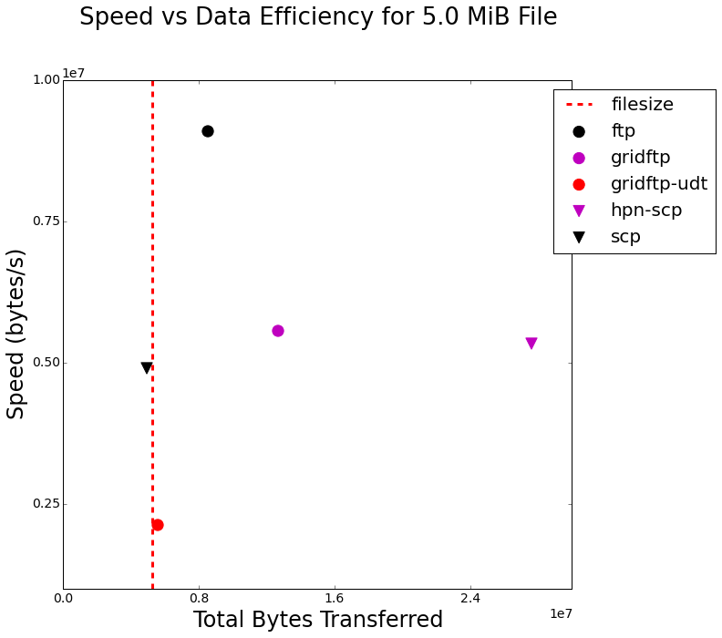

```python
%matplotlib inline
from matplotlib import pyplot as plt, rcParams
from ipywidgets import interact, fixed
import numpy as np
import pandas as pd

from plot import plot_speed_efficiency
from helpers import sizeof_fmt

LABEL_SIZE = 14

rcParams['figure.figsize'] = (10, 10)
rcParams['xtick.labelsize'] = LABEL_SIZE
rcParams['ytick.labelsize'] = LABEL_SIZE

# Group by Filesize and then Protocol
agg = df.groupby(["File Size (bytes)", "Protocol"]).aggregate(np.mean)
agg.drop(["Batch ID", "Stored Packets"], axis=1, inplace=True)

sizes = {str(sizeof_fmt(x)):x for x in set(df["File Size (bytes)"])}
agg_interact = interact(plot_speed_efficiency, df=fixed(agg), filesize=sizes)
```

```python
pd.set_option('display.float_format', lambda x: '%.1f' % x)

# print agg.reset_index().to_latex()
agg
```

| File Size (bytes) | Protocol | Bytes Down | Bytes Up | Bytes Total | Ratio (%) | Time (s) | Speed (bytes/s) |
| --- | --- | --- | --- | --- | --- | --- | --- |
| 5242880 | ftp | 8413007.7 | 110014.3 | 8523022.0 | 162.6 | 1.4 | 9092596.7 |
|  | gridftp | 7412012.0 | 5270788.4 | 12682800.4 | 241.9 | 1.3 | 5560789.2 |
|  | gridftp-udt | 5543205.4 | 6239.1 | 5549444.5 | 105.8 | 2.7 | 2121498.5 |
|  | hpn-scp | 5095229.0 | 22532226.6 | 27627455.6 | 527.0 | 1.0 | 5339580.5 |
|  | scp | 4808391.8 | 104417.7 | 4912809.5 | 93.7 | 1.0 | 4907455.3 |
| 536870912 | ftp | 534084205.9 | 1298533.8 | 535382739.7 | 99.7 | 24.4 | 22069687.9 |
|  | gridftp | 535240945.3 | 4425.0 | 535245370.3 | 99.7 | 25.3 | 21358608.5 |
|  | gridftp-udt | 553768959.7 | 173186.2 | 553942145.9 | 103.2 | 30.2 | 18732210.9 |
|  | hpn-scp | 535401726.9 | 164294.4 | 535566021.3 | 99.8 | 24.7 | 21895264.8 |
|  | scp | 535381827.3 | 185875.7 | 535567702.9 | 99.8 | 24.4 | 22088599.5 |
| 1073741824 | ftp | 1072881895.1 | 2558993.1 | 1075440888.1 | 100.2 | 47.1 | 22940550.1 |
|  | gridftp | 1071918333.8 | 4422.0 | 1071922755.8 | 99.8 | 47.6 | 22580395.8 |
|  | gridftp-udt | 1112012162.9 | 340049.3 | 1112352212.1 | 103.6 | 50.4 | 22086429.9 |
|  | hpn-scp | 1070826111.6 | 341411.1 | 1071167522.6 | 99.8 | 46.3 | 23154917.1 |
|  | scp | 1070596084.3 | 382239.0 | 1070978323.3 | 99.7 | 46.1 | 23375141.7 |
| 1610612736 | ftp | 1609012156.9 | 3810770.9 | 1612822927.7 | 100.1 | 68.3 | 23594127.5 |
|  | gridftp | 1608155406.3 | 4423.1 | 1608159829.5 | 99.8 | 70.5 | 22868925.7 |
|  | gridftp-udt | 1668742869.2 | 507308.4 | 1669250177.6 | 103.6 | 74.0 | 22557996.6 |
|  | hpn-scp | 1608701999.0 | 513687.6 | 1609215686.6 | 99.9 | 68.7 | 23465480.1 |
|  | scp | 1608169009.5 | 581313.7 | 1608750323.2 | 99.9 | 68.4 | 23536710.8 |
| 2147479552 | ftp | 2144495341.4 | 5166344.3 | 2149661685.7 | 100.1 | 100.0 | 21704026.4 |
|  | gridftp | 2145845215.4 | 4422.5 | 2145849637.9 | 99.9 | 95.0 | 22610027.5 |
|  | gridftp-udt | 2228159986.6 | 676775.8 | 2228836762.4 | 103.8 | 98.7 | 22581830.1 |
|  | hpn-scp | 2145264352.9 | 687628.8 | 2145951981.7 | 99.9 | 91.5 | 23476005.1 |
|  | scp | 2148226021.1 | 753291.0 | 2148979312.1 | 100.1 | 96.2 | 22467830.4 |
| 2540610608 | ftp | 2541336324.7 | 6128837.9 | 2547465162.6 | 100.3 | 118.9 | 21593507.4 |
|  | gridftp | 2538172141.5 | 4412.9 | 2538176554.4 | 99.9 | 114.3 | 22233098.8 |
|  | gridftp-udt | 2636682223.1 | 799058.2 | 2637481281.3 | 103.8 | 115.3 | 22868390.6 |
|  | hpn-scp | 2533961524.4 | 806759.9 | 2534768284.3 | 99.8 | 111.9 | 22745305.3 |
|  | scp | 2535048746.9 | 908753.4 | 2535957500.3 | 99.8 | 110.2 | 23077735.8 |

## Metrics per filesize

The above data can also be shown as two separate graphs, as a function of filesize.

## Speed

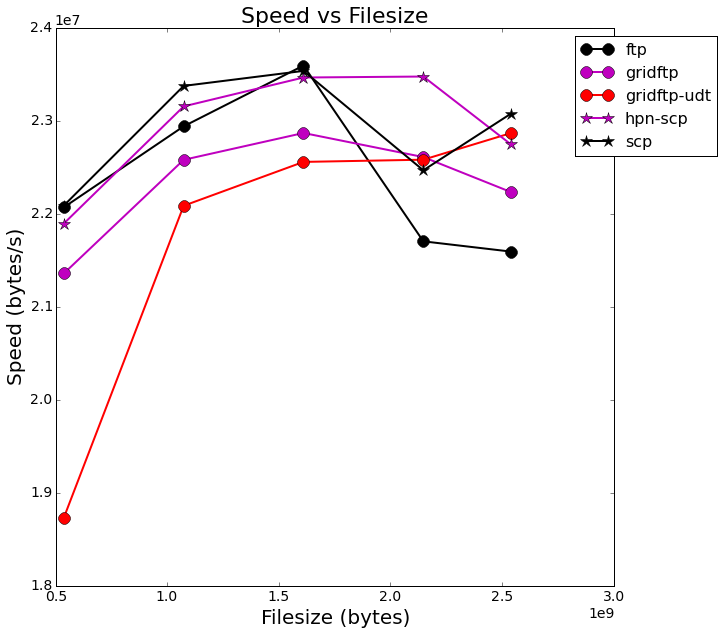

```python
%matplotlib inline
from plot import plot_speed_per_filesize

rcParams['figure.figsize'] = (10, 10)

plot_speed_per_filesize(df, ratio=False, ignore_small=True)
```

## Data Usage

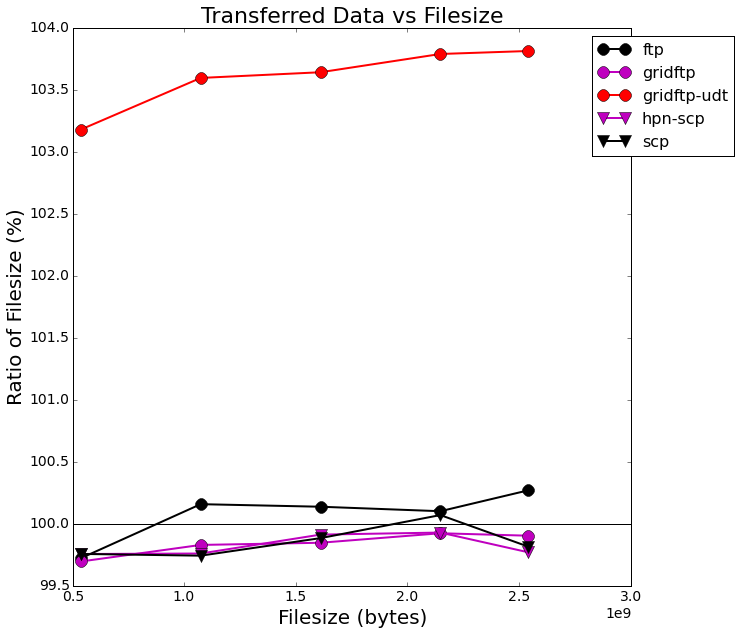

```python
%matplotlib inline
from plot import plot_data_per_filesize

rcParams['figure.figsize'] = (10, 10)

plot_data_per_filesize(df, ignore_small=True)
```

# Network stability

The network may be busier at certain times. If the tests are run at different hours of the day, this can be explored.

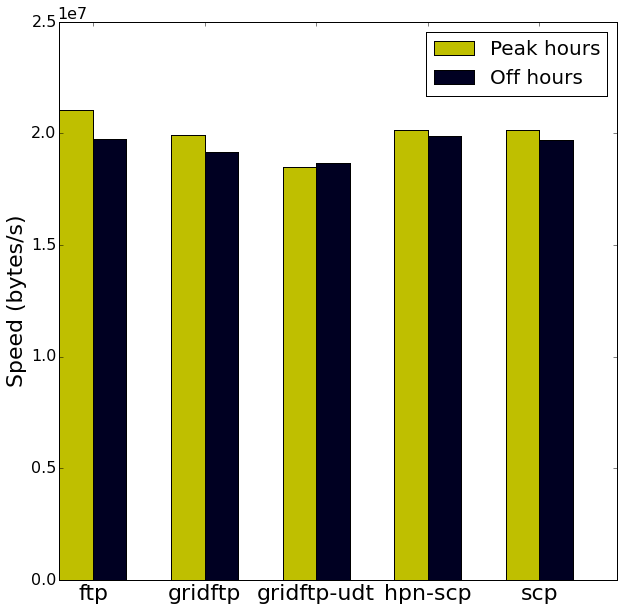

```python
%matplotlib inline
from datetime import time

from plot import plot_speed_day_night

LABEL_SIZE = 16
rcParams['figure.figsize'] = (10, 10)
rcParams['xtick.labelsize'] = LABEL_SIZE
rcParams['ytick.labelsize'] = LABEL_SIZE

# Group the data into working hours and off hours
t1 = time(11, 0 ,0)
t2 = time(15, 0, 0)
is_day = lambda x: t1 <= x.time() <= t2
day = df[[is_day(x) for x in df["Start Time"]]]
night = df[[not is_day(x) for x in df["Start Time"]]]

# Aggregate the frames by protocol, fetch their speed
get_speed = lambda df: df.groupby(["Protocol"]).aggregate(np.mean)["Speed (bytes/s)"]
speed_day = get_speed(day)
speed_night = get_speed(night)

plot_speed_day_night(speed_day, speed_night, title=False)
```

```python
from scipy import stats
import pandas as pd

print "The null hypothesis is that the samples have identical average (expected) values."
print "A value of None means that the data was not normal"
diff = pd.DataFrame(columns=set(day["Protocol"]))

for p in set(day["Protocol"]):
    a = day[day["Protocol"] == p]["Speed (bytes/s)"]
    b = night[night["Protocol"] == p]["Speed (bytes/s)"]
    if stats.normaltest(a)[1] > 0.05 or stats.normaltest(b)[1] > 0.05:
        diff[p] = [None]
    else:
        diff[p] = [stats.ttest_ind(a, b)[1]]

diff = diff.transpose()
diff.columns = ["p-value"]
# print diff.to_latex()
diff
```

```
The null hypothesis is that the samples have identical average (expected) values.
A value of None means that the data was not normal
```

|  | p-value |
| --- | --- |
| ftp | 0.4 |
| scp | 0.5 |
| hpn-scp | 0.7 |
| gridftp | 0.4 |
| gridftp-udt | 0.9 |

# Time taken

This is a practical point of view, and the graph that a non-technical user would care about.

The time to transfer the largest file size is plotted.

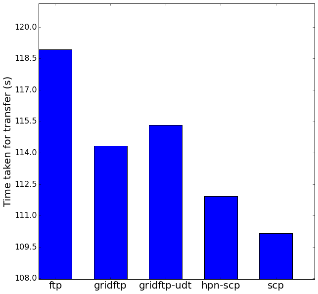

```python
from plot import plot_time

LABEL_SIZE = 16
rcParams['figure.figsize'] = (10, 10)
rcParams['xtick.labelsize'] = LABEL_SIZE
rcParams['ytick.labelsize'] = LABEL_SIZE

largest = max(agg.index.levels[0])
sel = agg.loc[largest]

plot_time(sel, title=False)
# sel
```

## Topography of Transfer

Displaying the packet sizes against a time axis gives more insight into each protocol. It's also a good representation of network conditions, as breaks or delays are easily seen.

```python
%matplotlib inline
import warnings

from plot import plot_packets

warnings.simplefilter('ignore', UserWarning)
rcParams['figure.figsize'] = (12, 12)

def reverse_lookup(bid):
    for key, val in ids.items():
        if val == bid:
            return key
    return None

batch_ids = {str(x):reverse_lookup(x) for x in set(df[df["Stored Packets"]]["Batch ID"])}

if batch_ids:
    packet_interact = interact(plot_packets, batch_id=batch_ids)
else:
    print "No batches with stored packets found"
    print "Run test.py with the --store-packets argument"
```

```
At least one protocol was missing from batch 7707605165168701577
```